# Final Project Lazada

```python
%%HTML
<script src="require.js"></script>
```

```python
from IPython.display import display, HTML
HTML(
    """
    <script
        src='https://cdnjs.cloudflare.com/ajax/libs/jquery/2.0.3/jquery.min.js'>
    </script>
    <script>
        code_show=true;
        function code_toggle() {
        if (code_show){
        $('div.jp-CodeCell > div.jp-Cell-inputWrapper').hide();
        } else {
        $('div.jp-CodeCell > div.jp-Cell-inputWrapper').show();
        }
        code_show = !code_show
        }
        $( document ).ready(code_toggle);
    </script>
    <form action='javascript:code_toggle()'>
        <input type="submit" value='Click here to toggle on/off the raw code.'>
    </form>
    """
)
```

```python
# Import libraries
import os
import time
import re

import json
from json.decoder import JSONDecodeError
import requests
from bs4 import BeautifulSoup

import numpy as np
import pandas as pd
import matplotlib.pyplot as plt
from wordcloud import WordCloud
from matplotlib.colors import LinearSegmentedColormap

from sklearn.metrics.pairwise import cosine_similarity
from sklearn.feature_extraction.text import TfidfVectorizer, CountVectorizer
from sklearn.metrics.pairwise import pairwise_distances
from sklearn.decomposition import NMF, TruncatedSVD
from sklearn.metrics import silhouette_score
```

[figure not shown]

# EXECUTIVE SUMMARY

[figure not shown]

In the dynamic world of e-commerce, customers, especially **new online shoppers**, often find themselves lost in a sea of products. These users, unfamiliar with the nuances of digital shopping, struggle to find a starting point, leading to a frustrating experience. This not only makes the platform less appealing but also affects the visibility and sales of its sellers. To tackle this, our team is focused on making the online shopping experience smoother and more intuitive.

Our goal is to make e-commerce platforms easier to navigate and more user-friendly, especially for newcomers. By refining the number of product categories with our specialized analysis, we aim to simplify the shopping process. This won't just help users find what they need faster, but also boost the platform's overall appeal. For sellers, this means better visibility and potentially more sales, as products are categorized more logically. In short, our solution is all about making online shopping a breeze for users and more profitable for sellers.

# PROBLEM STATEMENT

[figure not shown]

In the world of online retail, it's crucial to get product categorization just right. This is especially true for big platforms like Lazada, where the sheer variety of products can be overwhelming. We're looking at a challenge that's not just about slapping labels on products. It's about diving deep into what shoppers want, keeping up with market trends, and really getting what makes Lazada's range of products special.

It's about making shopping easy and enjoyable for users while ensuring that sellers can effectively showcase their products. The real task is to sift through Lazada's extensive inventory, keep up with what customers want, and boil it all down to key categories. We're focused on one main question:

### What are the key categories that truly represent Lazada's platform?

# MOTIVATION

[figure not shown]

Our project has created a more user-friendly e-commerce platform, using data analysis and web scraping to improve product layout. This leads to an easier and more intuitive shopping experience, where customers can find and select products without hassle. The platform's new design is not just about functionality, but also about providing a pleasant and straightforward browsing experience.

**The main goal of this initiative is to simplify online shopping, making it less overwhelming and more enjoyable for customers. We've focused on streamlining navigation, cutting down on excessive choices, and organizing products in a clear way. This approach is aimed at increasing customer satisfaction, which we anticipate will lead to higher sales and stronger customer loyalty.**

Our target market includes new online shoppers who might find traditional e-commerce platforms challenging, as well as regular users looking for a more efficient shopping experience. Additionally, the improved platform is beneficial for sellers, providing them with a better way to showcase their products and connect with their audience. Ultimately, our project is designed to enhance the shopping experience for everyone involved in the e-commerce process.

# METHODOLOGY OVERVIEW

[figure not shown]

Represented in **Table 1. Methology Overview** are the steps the team has taken to address the problem statement.

##### **Table 1. Methology Overview**

| Step | Process | Description |
| --- | --- | --- |
| 1 | Data Extraction and Cleaning | Extract category tree data from Lazada API and use data to webscrape listings and category details from Lazada website |
| 2 | Exploratory Data Analysis | Perform EDA to gain understanding on the data and its characteristics, and identify any trends |
| 3 | Data Vectorization | Represent text as vectors through bag-of-words representation with TF-IDF |
| 3 | Dimensionality Reductions | Reduce these vectorized data into 7 topics which will be the set of new categories |
| 5 | Results | Utilize silhouette score to identify the optimal number of topics that will make sense |
| 6 | Insights and Recommendation | Summarize the insights from the generated results, and provide recommendations given the insights acquired |

### DATA SCOPE AND LIMITATIONS

[figure not shown]

# DATA EXTRACTION AND CLEANING

[figure not shown]

The data extraction and cleaning process was conducted in three main phases:

1. Initial data on the category tree of Lazada was extracted from the Lazada API.
2. Using information gathered from the category tree, the team utilized the `get` function from the imported `requests` library to webscrape the listings data of the first five pages for every category path.
3. For category paths with missing entries, the team utilized the `get` function to collect the first five pages based on the Lazada search query to obtain the link for the category path landing page.

## LAZADA CATEGORY TREE DATA

[figure not shown]

### Extract Category Tree Data from Lazada API

[figure not shown]

The initial data was extracted by gaining access to the Lazada API available to Lazada sellers and developers. Part of the available information in the Lazada API includes the category tree, with details of the category name, ID, and its sub-categories or "children". The data can be access via the API via the following steps:

1. Select "Philippines" as the Region.
2. To create an app key, apply first in content management.
3. This will provide access to management of product listing, including product title, image, or price.
4. It will take utmost 3 working days in the approval.
5. Type '/category/attributes/get' in API Path.
6. HTTP Method is automatically GET.
7. Click 'Access Token' and the it will be generated.
8. Set Parameters primary_category_id and language_code to 8704 and en_US respectively.

The request is illustrated as well in the **Figure 1. Lazada API Category Tree Request Get.**

[figure not shown]

##### **Figure 1. Lazada API Category Tree Request Get**

```python
with open('lazada_category_tree.json', 'r') as json_file:
    lzd_cat_tree = json.load(json_file)
```

Loading the JSON file obtained from the API, we can view a snapshot from the Lazada Category Tree on the available details.

```python
lzd_cat_tree['data'][0]['children'][0]['children'][0]['children']
```

```
[{'var': False, 'name': 'Tents', 'leaf': True, 'category_id': 7665},
 {'children': [{'var': False,
    'name': 'Sleeping Bags',
    'leaf': True,
    'category_id': 7666},
   {'var': False,
    'name': 'Air Mattresses',
    'leaf': True,
    'category_id': 10120},
   {'var': False, 'name': 'Sleeping Pads', 'leaf': True, 'category_id': 10121},
   {'var': False,
    'name': 'Pillows & Accessories',
    'leaf': True,
    'category_id': 10122},
   {'var': False, 'name': 'Cots', 'leaf': True, 'category_id': 21730},
   {'var': False, 'name': 'Hammocks', 'leaf': True, 'category_id': 21731}],
  'var': False,
  'name': 'Sleeping Gear',
  'leaf': False,
  'category_id': 10119},
 {'var': False,
  'name': 'Shelters & Canopies',
  'leaf': True,
  'category_id': 10128},
 {'children': [{'var': False,
    'name': 'Backpack covers',
    'leaf': True,
    'category_id': 14532},
   {'var': False,
    'name': 'Hiking Backpacks',
    'leaf': True,
    'category_id': 21733},
   {'var': False,
    'name': 'Hydration Packs',
    'leaf': True,
    'category_id': 21734},
   {'var': False, 'name': 'Waist Packs', 'leaf': True, 'category_id': 21735}],
  'var': False,
  'name': 'Backpacks',
  'leaf': False,
```

[output cut: 45 more lines]

```
   {'var': False,
    'name': 'Emergency Light Sticks',
    'leaf': True,
    'category_id': 21751}],
  'var': False,
  'name': 'Lighting',
  'leaf': False,
  'category_id': 21746},
 {'var': False,
  'name': 'Navigation & Electronics',
  'leaf': True,
  'category_id': 21750},
 {'var': False, 'name': 'Trekking Poles', 'leaf': True, 'category_id': 21752},
 {'var': False, 'name': 'Knives & Tools', 'leaf': True, 'category_id': 21753},
 {'var': False, 'name': 'Survival kits', 'leaf': True, 'category_id': 21754}]
```

### Consolidate Category Path strings and corresponding Category IDs per path into Dictionary

[figure not shown]

```python
def generate_category_paths(cat_dict, current_cat_path=''):
    """Generate category paths from parent category until last sub-category"""
    cat_path_list = []
    current_cat_path += cat_dict['name']

    if 'children' in cat_dict:
        for child in cat_dict['children']:
            cat_path_list.extend(
                generate_category_paths(child, current_cat_path + ' > '))

    if 'leaf' in cat_dict and cat_dict['leaf']:
        cat_path_list.append(current_cat_path)

    return cat_path_list
```

```python
all_cat_path_list = []

for main_cat in lzd_cat_tree['data']:
    all_cat_path_list.extend(generate_category_paths(main_cat))
```

```python
def generate_category_id_paths(cat_dict,
                               current_cat_path='',
                               current_id_path=''):
    """Generate category ID paths from parent category until last sub-category"""
    id_path_list = []
    current_cat_path += cat_dict['name']
    current_id_path += str(cat_dict['category_id'])

    if 'children' in cat_dict:
        for child in cat_dict['children']:
            id_path_list.extend(
                generate_category_id_paths(
                    child, current_cat_path + ' > ', current_id_path + ' > '))

    if 'leaf' in cat_dict and cat_dict['leaf']:
        id_path_list.append(current_id_path)

    return id_path_list
```

```python
all_id_path_list = []

for main_cat in lzd_cat_tree['data']:
    all_id_path_list.extend(generate_category_id_paths(main_cat))
```

```python
cat_id_path_dict = dict(zip(all_cat_path_list, all_id_path_list))
```

Using the category tree obtained from the API, the complete category & sub-category combinations were consolidated into corresponding paths alongside the corresponding category IDs. The two sets of data were zipped into a dictionary, with keys referring to the category path and values as the category ID paths.

The functions `generate_category_paths` and `generate_category_id_paths` were run to generate the two lists before being zipped.

Displayed below is a sample snippet of the resulting Lazada Category Path-ID dictionary.

```python
list(cat_id_path_dict.items())[:5]
```

```
[('Sports & Outdoors > Outdoor Recreation > Camping & Hiking > Tents',
  '4623 > 7654 > 7657 > 7665'),
 ('Sports & Outdoors > Outdoor Recreation > Camping & Hiking > Sleeping Gear > Sleeping Bags',
  '4623 > 7654 > 7657 > 10119 > 7666'),
 ('Sports & Outdoors > Outdoor Recreation > Camping & Hiking > Sleeping Gear > Air Mattresses',
  '4623 > 7654 > 7657 > 10119 > 10120'),
 ('Sports & Outdoors > Outdoor Recreation > Camping & Hiking > Sleeping Gear > Sleeping Pads',
  '4623 > 7654 > 7657 > 10119 > 10121'),
 ('Sports & Outdoors > Outdoor Recreation > Camping & Hiking > Sleeping Gear > Pillows & Accessories',
  '4623 > 7654 > 7657 > 10119 > 10122')]
```

```python
print(
    f'Total number of category & sub-category combinations: '
    f'{len(cat_id_path_dict)}')
```

```
Total number of category & sub-category combinations: 4489
```

### Limit Category Paths to Maximum Three Levels

[figure not shown]

```python
third_level_dict = {key: value for key, value in cat_id_path_dict.items()
                    if key.count('>') <= 2}
```

The data was further reduced in scope by limiting the category paths explored down to the third level maximum.

```python
list(third_level_dict.items())[:10]
```

```
[('Mobiles & Tablets > Landline Phones', '5116 > 5118'),
 ('Mobiles & Tablets > Tablets', '5116 > 5120'),
 ('Mobiles & Tablets > Smartphones', '5116 > 5121'),
 ('Mobiles & Tablets > Feature Phones', '5116 > 42006401'),
 ('Computers & Laptops > Desktops Computers > All-In-One',
  '5141 > 5148 > 11151'),
 ('Computers & Laptops > Desktops Computers > Gaming Desktops',
  '5141 > 5148 > 11153'),
 ('Computers & Laptops > Desktops Computers > DIY', '5141 > 5148 > 11155'),
 ('Computers & Laptops > Laptops > Gaming Laptops', '5141 > 5149 > 7093'),
 ('Computers & Laptops > Laptops > Traditional Laptops',
  '5141 > 5149 > 11147'),
 ('Computers & Laptops > Laptops > 2-in-1s', '5141 > 5149 > 13836')]
```

```python
print(f'Reduced number of category & sub-category combinations: '
      f'{len(third_level_dict)}')
```

```
Reduced number of category & sub-category combinations: 1365
```

### Consolidate Last Category Name of each Category Path

[figure not shown]

```python
third_level_cat_list = [re.search(r'[^>]+$', cat_path).group().strip()
                        for cat_path in third_level_dict.keys()]
third_level_cat_unique = sorted(list(set(third_level_cat_list)))
```

In preparation for the webscraping process, the unique third level category names must be consolidated. These will be utilized as part of the endpoint in the `requests.get` functionality.

Displayed below is a sample snippet of the unique third level categories, from 1,300+ category paths down to 1,200+.

```python
third_level_cat_unique[:10]
```

```
['2-in-1s',
 '3-D Puzzles',
 '360 Cameras',
 '3D Glasses',
 '3D Printer Parts',
 '3D Printers',
 '3D Printing Materials',
 'Accessories',
 'Action',
 'Action Figures']
```

```python
print(f'Number of unique third level categories: {len(third_level_cat_unique)}')
```

```
Number of unique third level categories: 1202
```

## LAZADA LISTINGS DATA PER CATEGORY PATH

[figure not shown]

### Webscrape the Listing details per Lazada Category Path

[figure not shown]

```python
def webscrape_category_listings(start, end, headers):
    """Webscrape Lazada website based on third level category name"""
    start_index = start
    end_index = end
    conso_df = pd.DataFrame()

    for product_to_categorize in third_level_cat_unique[start_index:end_index]:
        product_to_categorize = (product_to_categorize
                                 .strip()
                                 .lower()
                                 .replace(' & ', '-')
                                 .replace(' ', '-')
                                 .replace(',', ''))
        products_info = []

        for page_number in list(range(1, 6)):
            try:
                lzd = requests.get(
                    f'https://www.lazada.com.ph/shop-{product_to_categorize}/'
                    f'?ajax=true&isFirstRequest=true&page={page_number}',
                    headers=headers).json()
                time.sleep(10)

            except JSONDecodeError as e:
                print(f'JSONDecodeError: {e} - category {start}')
                continue

            for item in lzd.get('mods', {}).get('listItems', []):
                info = {
                    'name': item.get('name', ''),
                    'item_id': item.get('itemId', ''),
                    'category_id': item.get('categories', ''),
                    'discount': item.get('discount', ''),
                    'rating_score': item.get('ratingScore', ''),
                    'original_price': item.get('originalPrice', ''),
                    'price': item.get('price', ''),
                    'item_sold_count': item.get('itemSoldCntShow', ''),
                    'temp_category_index': f'{start}'
                }
                products_info.append(info)

        df = pd.DataFrame(products_info)
        conso_df = pd.concat([conso_df, df], ignore_index=True)
        start += 1

    return conso_df
```

```python
# Initialize with the following sample parameters
headers = {
    'Accept': 'application/json, text/plain, */*',
    'Accept-Encoding': 'gzip, deflate, br',
    'Accept-Language': 'en-US,en;q=0.9',
    'Cookie': ('__wpkreporterwid_=3fe582be-6d6e-463d-3dd1-7ba13b5f49ff; lzd_cid'
               '=c1add782-8880-4a9d-d2bb-4f998db23cac; t_uid=c1add782-8880-4a9d'
               '-d2bb-4f998db23cac; t_fv=1700280938528; lwrid=AQGL4KQwN3O1ot2bK'
               '%2Fk8X39uI9jH; hng=PH|en-PH|PHP|608; userLanguageML=en; cna=aij'
               'fHTBRfhwCAZJYTCK8Xjwt; _bl_uid=sjlw3p763azjLddv7lz8891g7F3t; __'
               'itrace_wid=4233bd3d-25b0-4ee9-1268-986e501061b0; _gcl_au=1.1.21'
               '01806292.1700281477; _uetvid=6ba4d9c085ca11eebfadd5053eb33830; '
               '_fbp=fb.2.1700281493102.857291082; sgcookie=E100FFrZs3pSnXrfa2Q'
               '2e%2Bre9%2FsIir3s1C7cJ8gyw8N7OMRCBzqJVoFhm2eUXftZ4YyNV0uOqIh%2B'
               'KIxoC92rlMcbcajjzryCMH2lYyYlCUC%2FIuQ%3D; pdp_sfo=1; lzd_sid=16'
               '2bc36d95867700f181066e84f26ad3; _tb_token_=ee7eb7896fe78; xlly_'
               's=1; tfstk=dHDyqBXhILpzir4W672U3K10An28eRL_-vaQxDm3Vz4lFT_ngq3F'
               'A3LpwjzEoqP3Rvwu-Mumx7b7F06ETD4VdzaB2xPERVB7rvodLkmnJ3UB2Ii-2Je'
               'H5FweC7nJwTY653qYOm2LKFT6OwnUKJ3wy0ARUS3PvT9uMFmToYKhjxUN3yaVKO'
               'SY470eBrWHIxrrIPXNEwE09vMKawfUZoE45n-4GuITT; t_sid=0FQ3cJ68EG1q'
               'kLeMDfm3pOBWZ3FLai4t; utm_channel=NA; _m_h5_tk=fa815492ff2071e1'
               '41c62cb96ab0ecc3_1700766922943; _m_h5_tk_enc=095022a4c1e0fc028d'
               '7df7af3bcb3df5; epssw=1*ic1611iDjCECG_GS7zFQK79Stdfw8Pz4IlmYNez'
               '4urz8BgedNR_8uVz8t0wTfhdWH96VIL5jgzJS11Gz1Apx7UeoHfBW-5CWH1BWsC'
               'nPE91G_rYp3hYKNtCOeGxGf8tGj3mOvpCt9rLauayuv1Rug5NYmahdkQURII7_-'
               '20krTB4hUHJ3zQRxDDR3DqheKz5PKBvetzRGbvOGb1j_Q1JcPczBF3tet4Rh43-'
               'yaBp; isg=BLe3W9-qntHRBRpaw_-3p1ODRqsBfIve2IjgfAlk0wbtuNf6EUwbL'
               'nWemhDma2NW'),
    'Referer': 'https://www.lazada.com.ph/',
    'Sec-Ch-Ua': ('"Google Chrome";v="119", "Chromium";v="119", "Not?A_Brand";'
                  'v="24"'),
    'Sec-Ch-Ua-Mobile': '?0',
    'Sec-Ch-Ua-Platform': '"Windows"',
    'Sec-Fetch-Dest': 'empty',
    'Sec-Fetch-Mode': 'cors',
    'Sec-Fetch-Site': 'same-origin',
    'User-Agent': ('Mozilla/5.0 (Windows NT 10.0; Win64; x64) '
                   'AppleWebKit/537.36 (KHTML, like Gecko) '
                   'Chrome/119.0.0.0 Safari/537.36'),
    'X-Csrf-Token': 'ee7eb7896fe78',
    'X-Requested-With': 'XMLHttpRequest'
}

start_1 = 300
end_1 = 301

start_2 = 305
end_2 = 306
```

```python
sample_webscrape_df_1 = webscrape_category_listings(start_1, end_1, headers)
```

```python
sample_webscrape_df_2 = webscrape_category_listings(start_2, end_2, headers)
```

With the third level category names consolidated, the initial webscrape run can be initiated, with the steps as follows.

##### 1. Each category name is converted into a format that can be inputted into the target endpoint of the `requests.get` function, as presented in Table 2.

[figure not shown]

##### **Table 2. Lazada API Category Tree Request Get**

| Sample Input | Reformatted Input |
| --- | --- |
| Landline Phones | landline-phones |
| 3-D Puzzles | 3-d-puzzles |
| Art Pads, Diaries & Folios | art-pads-diaries-folios |

##### 2. Once the endpoint is created, a request is created to the Lazada URL endpoint to arrive at the category path landing page.

[figure not shown]

- The process takes advantage of the identified pattern in the endpoint for the landing page of each category path combination.
- Categories are pulled in small sets in order to manage potential errors resulting from Captcha requests from the Lazada website.
- Cookies are updated every few pulls in order to manage potential errors resulting from Captcha requests from the Lazada website.

  **NOTE:** Headers are unique per user and must be updated in order to run the code successfully.

##### 3. The process will iterate through each of the listings in the first landing page and collect the request info such as the product name, category_id path, price and other details.

[figure not shown]

##### 4. After retrieving all relevant info from the first page, the process iterates through the remaining of the first five pages of the requested category path and saved into a dataframe.

[figure not shown]

##### 5. Lastly, the generated DataFrame is saved into a CSV file, for consolidation once all runs have been completed.

[figure not shown]

- Method to save DataFrames into CSV files per pull in order to avoid loss of data in case of crash

Displayed below are two sample snippets of the listings info collected, returning DataFrames from the function `webscrape_category_listings`.

```python
sample_webscrape_df_1.head()
```

|  | name | item_id | category_id | discount | rating_score | original_price | price | item_sold_count | temp_category_index |
| --- | --- | --- | --- | --- | --- | --- | --- | --- | --- |
| 0 | SRG Christmas Giving Tree P10 | 3354849788 | [12576, 24735, 21018201] |  | 5.0 |  | 10 | 93 sold | 300 |
| 1 | Spring Rain Global: Care for the Indigenous Pe... | 723918107 | [12576, 24735, 21018201] |  | 5.0 |  | 500 | 19 sold | 300 |
| 2 | 1 Dollar per Day for 100 Days Campaign by SRG | 4222496808 | [12576, 24735, 21018201] |  | 0 |  | 50 |  | 300 |
| 3 | Spring Rain Global Care for Disaster Response ... | 1407070805 | [12576, 24735, 21018201] |  | 4.921568627450981 |  | 20 | 227 sold | 300 |
| 4 | 5 PESOS FOR DUMAGAT COMMUNITY IN NAKAR BULACAN | 2985533224 | [12576, 24735, 21018201] |  | 0 |  | 5 | 18 sold | 300 |

```python
sample_webscrape_df_2.head()
```

|  | name | item_id | category_id | discount | rating_score | original_price | price | item_sold_count | temp_category_index |
| --- | --- | --- | --- | --- | --- | --- | --- | --- | --- |
| 0 | 180ml Kuelox Fixative Spray For Sketch/Gouache... | 2206122392 | [22393, 22430, 22744] | 24% Off | 4.879432624113475 | 139 | 105.04 | 721 sold | 305 |
| 1 | Crayola Crayons Set of 8, 16 or 24 colors | 2716668362 | [22393, 22430, 22744] | 63% Off | 4.946356951871658 | 39 | 14.47 | 9,999+ sold | 305 |
| 2 | 24 Colors Alcohol Marker Art Marker Highlighte... | 3617947502 | [22393, 22430, 22744] | 55% Off | 5.0 | 200 | 89.63 | 94 sold | 305 |
| 3 | Professional sketchbook Thick paper 160 notebo... | 3709686910 | [22393, 22430, 22744] | 76% Off | 4.928571428571429 | 199 | 48 | 402 sold | 305 |
| 4 | Crayola Crayons Set of 8, 16 or 24 colors | 2716702418 | [22393, 22430, 22744] | 62% Off | 4.949335889360537 | 39 | 14.77 | 100k+ sold | 305 |

```python
sample_webscrape_df_1.to_csv(f'{start_1}-{end_1-1}.csv')
sample_webscrape_df_2.to_csv(f'{start_2}-{end_2-1}.csv')
```

### Consolidate CSV Files into a DataFrame

[figure not shown]

```python
# Change dir_path to be robust
```

```python
def consolidate_csv_to_df():
    """Consolidate multiple CSV files to single DataFrame"""
    dir_path = dir_path
    files = os.listdir(dir_path)
    csv_files = [file for file in files
                 if re.match(r'\d+-\d+', file) and file.endswith('.csv')]

    sample_conso_df = pd.DataFrame()
    for file in csv_files:
        df = pd.read_csv(os.path.join(dir_path, file))
        sample_conso_df = pd.concat([sample_conso_df, df], ignore_index=True)
        sample_conso_df.drop_duplicates(
            subset=['item_id'], inplace=True, ignore_index=True)

    return sample_conso_df
```

```python
sample_conso_df = consolidate_csv_to_df()
```

The CSV files are then loaded and concatenated into a single dataframe and the duplicates based on `item_id` are dropped, using the `consolidate_csv_to_df` function.

Displayed below is a sample of two CSV file consolidated into a DataFrame.

```python
sample_conso_df.head()
```

|  | Unnamed: 0 | name | item_id | category_id | discount | rating_score | original_price | price | item_sold_count | temp_category_index |
| --- | --- | --- | --- | --- | --- | --- | --- | --- | --- | --- |
| 0 | 0 | SRG Christmas Giving Tree P10 | 3354849788 | [12576, 24735, 21018201] | NaN | 5.000000 | NaN | 10.0 | 93 sold | 300 |
| 1 | 1 | Spring Rain Global: Care for the Indigenous Pe... | 723918107 | [12576, 24735, 21018201] | NaN | 5.000000 | NaN | 500.0 | 19 sold | 300 |
| 2 | 2 | 1 Dollar per Day for 100 Days Campaign by SRG | 4222496808 | [12576, 24735, 21018201] | NaN | 0.000000 | NaN | 50.0 | NaN | 300 |
| 3 | 3 | Spring Rain Global Care for Disaster Response ... | 1407070805 | [12576, 24735, 21018201] | NaN | 4.921569 | NaN | 20.0 | 227 sold | 300 |
| 4 | 4 | 5 PESOS FOR DUMAGAT COMMUNITY IN NAKAR BULACAN | 2985533224 | [12576, 24735, 21018201] | NaN | 0.000000 | NaN | 5.0 | 18 sold | 300 |

```python
print(f'Total listings from the two sample runs: {len(sample_conso_df)}')
```

```
Total listings from the two sample runs: 400
```

```python
first_run_lzd_df = pd.read_csv('first_run_lzd_df.csv')
del first_run_lzd_df[first_run_lzd_df.columns[0]]
```

The unnecessary column was then removed from the consolidated DataFrame.

The snippet of the clean DataFrame is shown below.

```python
first_run_lzd_df.head()
```

|  | name | item_id | category_id | discount | rating_score | original_price | price | item_sold_count | temp_category_index |
| --- | --- | --- | --- | --- | --- | --- | --- | --- | --- |
| 0 | 【☞☞】【3Years Warranty】Original cctv camera conn... | 2.801853e+09 | [5185, 5200, 24956] | 56% Off | 5.0 | 1799.0 | 799.00 | 1,861 sold | 2.0 |
| 1 | MOK FWRD DEVICE MOK FRWRD | 4.040168e+09 | [5185, 5200, 24956] | 49% Off | 5.0 | 1990.0 | 1010.00 | 14 sold | 2.0 |
| 2 | Insta360 Bullet Time Accessory Bundle for ONE ... | 5.587683e+08 | [5185, 5200, 24956] | NaN | 4.0 | NaN | 2590.00 | 14 sold | 2.0 |
| 3 | V380 USB Wifi Camera With SD Card Recorder | 1.627659e+09 | [5185, 5200, 24956] | 57% Off | 0.0 | 1599.0 | 693.55 | NaN | 2.0 |
| 4 | [Ready Stock] Obsbot Tiny 4k + Remote Control | 3.410223e+09 | [5185, 5200, 24956] | NaN | 0.0 | NaN | 15819.00 | NaN | 2.0 |

```python
print(f'Total listings collected on first webscrape run: '
      f'{len(first_run_lzd_df)}')
```

```
Total listings collected on first webscrape run: 81926
```

## LAZADA LISTINGS DATA USING SEARCH QUERY

[figure not shown]

### Prepare Data for Identification of Uncaptured Listing Entries

[figure not shown]

```python
def get_third_or_second_category_id(cat_id_path):
    """Retrieve third or second level category ID from category_id column"""
    match_third = re.search(
        r'(?:\[(?:\d+\s*,\s*){2}(\d+)(?:\s*,\s*\d+\s*)*\])', cat_id_path)
    match_second = re.search(
        r'\[(?:\d+\s*,\s*(\d+)(?:\s*,\s*\d+\s*)?)\]', cat_id_path)

    if match_third:
        return int(match_third.group(1))
    else:
        return int(match_second.group(1))
```

```python
def create_third_category_id_col(df, cat_id_col, third_cat_id_col):
    """Create additional column consisting of third_category_id"""
    df[third_cat_id_col] = df[cat_id_col].apply(
        lambda x: get_third_or_second_category_id(x))

    return df
```

```python
first_run_lzd_df = create_third_category_id_col(
    first_run_lzd_df, 'category_id', 'third_category_id')
```

In preparation for identifying the missing categories, the `third_category_id` was added to the consolidated DataFrame, using two functions. Firstly, the `get_third_or_second_category` function successfully captures the third level category from each `category_id` column values. This is used in conjunction with the `create_third_category_id_col` function in order to create the additional `third_category_id` column to the DataFrame.

The snippet of the DataFrame is shown below.

```python
first_run_lzd_df.head()
```

|  | name | item_id | category_id | discount | rating_score | original_price | price | item_sold_count | temp_category_index | third_category_id |
| --- | --- | --- | --- | --- | --- | --- | --- | --- | --- | --- |
| 0 | 【☞☞】【3Years Warranty】Original cctv camera conn... | 2.801853e+09 | [5185, 5200, 24956] | 56% Off | 5.0 | 1799.0 | 799.00 | 1,861 sold | 2.0 | 24956 |
| 1 | MOK FWRD DEVICE MOK FRWRD | 4.040168e+09 | [5185, 5200, 24956] | 49% Off | 5.0 | 1990.0 | 1010.00 | 14 sold | 2.0 | 24956 |
| 2 | Insta360 Bullet Time Accessory Bundle for ONE ... | 5.587683e+08 | [5185, 5200, 24956] | NaN | 4.0 | NaN | 2590.00 | 14 sold | 2.0 | 24956 |
| 3 | V380 USB Wifi Camera With SD Card Recorder | 1.627659e+09 | [5185, 5200, 24956] | 57% Off | 0.0 | 1599.0 | 693.55 | NaN | 2.0 | 24956 |
| 4 | [Ready Stock] Obsbot Tiny 4k + Remote Control | 3.410223e+09 | [5185, 5200, 24956] | NaN | 0.0 | NaN | 15819.00 | NaN | 2.0 | 24956 |

### Identify Categories with Uncaptured Listing Entries

[figure not shown]

```python
def retrieve_uncaptured_categories(df):
    """Retrieve category paths with uncaptured listing entries"""
    pattern = r'(\d+)\b'
    captured_cat_ids = list(df['third_category_id'].unique())
    uncaptured_cats = []

    for cat, cat_ids in third_level_dict.items():
        cat_id_matches = re.findall(pattern, cat_ids)
        if int(cat_id_matches[-1]) not in captured_cat_ids:
            cat = cat.replace(' > ', ' ')
            uncaptured_cats.append(cat)

    return uncaptured_cats
```

```python
def retrieve_uncaptured_last_categories(df):
    """Retrieve third level sub-categories of uncaptured listing categories"""
    pattern = r'[^>]+$'
    captured_cat_ids = list(df['third_category_id'].unique())
    uncaptured_last_cats = []

    for cat, cat_ids in third_level_dict.items():
        cat_id_matches = re.findall(pattern, cat_ids)
        cat_matches = re.findall(pattern, cat)
        if int(cat_id_matches[-1]) not in captured_cat_ids:
            uncaptured_last_cats.append(cat_matches[0].strip())

    return uncaptured_last_cats
```

```python
uncaptured_cats = retrieve_uncaptured_categories(first_run_lzd_df)
uncaptured_last_cats = retrieve_uncaptured_last_categories(first_run_lzd_df)
```

Categories and their corresponding last categories are identified and separated into two different lists in preparation for the next step, using functions `retrieve_uncaptured_categories` and `retrieve_uncaptured_last_categories` respectively.

Below is a snippet of the uncaptured categories and its corresponding last categories, respectively.

```python
uncaptured_cats[:10]
```

```
['Mobiles & Tablets Smartphones',
 'Mobiles & Tablets Feature Phones',
 'Computers & Laptops Desktops Computers All-In-One',
 'Computers & Laptops Desktops Computers DIY',
 'Computers & Laptops Laptops 2-in-1s',
 'Cameras & Drones Bridge',
 'Cameras & Drones Video & Action Camcorder Underwater Camcorders',
 'Cameras & Drones Video & Action Camcorder Sports & Action Camera',
 'Cameras & Drones Video & Action Camcorder Video Camera',
 'Cameras & Drones Instant Camera Instant Cameras']
```

```python
uncaptured_last_cats[:10]
```

```
['Smartphones',
 'Feature Phones',
 'All-In-One',
 'DIY',
 '2-in-1s',
 'Bridge',
 'Underwater Camcorders',
 'Sports & Action Camera',
 'Video Camera',
 'Instant Cameras']
```

### Retrieve URLs for Categories with Uncaptured Listings with Search Query

[figure not shown]

```python
cat_url_dct = {}
```

```python
def retrieve_uncaptured_category_urls(start, end, headers):
    """Webscrape Lazada to retrieve URLs of uncapture category listings"""
    i = 0
    for cat in uncaptured_cats[start:end]:
        try:
            lzd = requests.get('https://www.lazada.com.ph/catalog/',
                         headers=headers, params={'q': f'{cat}'}).text
            time.sleep(5)

        except JSONDecodeError as e:
            print(f'JSONDecodeError: {e}')
            continue

        soup = BeautifulSoup(lzd, 'html.parser')
        script_tags = soup.find_all('script')
        script_tags = soup.find_all(
            'script', {'class': re.compile(r'J_data_\d+')})

        child_cat_names = []
        child_cat_urls = []

        for script in script_tags:
            content = script.string.strip()
            json_content = re.search(r'\[{.*}\]', content)

            if json_content:
                json_data = json_content.group()
                data = json.loads(json_data)

                for item in data:
                    name = item.get('childCategoryName')
                    url = item.get('childCategoryUrl')

                    if name and url:
                        child_cat_names.append(name)
                        child_cat_urls.append(url)

        data = {
            'child_cat_name': child_cat_names,
            'child_cat_url': child_cat_urls
        }
        df = pd.DataFrame(data)
        df = df.drop_duplicates(subset='child_cat_name')
        df = df.reset_index(drop=True)

        url = (df[df['child_cat_name'] ==
                  f'{uncaptured_last_cats[i+start]}']['child_cat_url'])
        cat_url_dct[cat] = url
        i += 1
```

```python
# Initialize with the following sample parameters
headers = {
    'Accept': 'application/json, text/plain, */*',
    'Accept-Encoding': 'gzip, deflate, br',
    'Accept-Language': 'en-US,en;q=0.9',
    'Cookie': ('__wpkreporterwid_=3fe582be-6d6e-463d-3dd1-7ba13b5f49ff; lzd_cid'
               '=c1add782-8880-4a9d-d2bb-4f998db23cac; t_uid=c1add782-8880-4a9d'
               '-d2bb-4f998db23cac; t_fv=1700280938528; lwrid=AQGL4KQwN3O1ot2bK'
               '%2Fk8X39uI9jH; hng=PH|en-PH|PHP|608; userLanguageML=en; cna=aij'
               'fHTBRfhwCAZJYTCK8Xjwt; _bl_uid=sjlw3p763azjLddv7lz8891g7F3t; __'
               'itrace_wid=4233bd3d-25b0-4ee9-1268-986e501061b0; _gcl_au=1.1.21'
               '01806292.1700281477; _uetvid=6ba4d9c085ca11eebfadd5053eb33830; '
               '_fbp=fb.2.1700281493102.857291082; sgcookie=E100FFrZs3pSnXrfa2Q'
               '2e%2Bre9%2FsIir3s1C7cJ8gyw8N7OMRCBzqJVoFhm2eUXftZ4YyNV0uOqIh%2B'
               'KIxoC92rlMcbcajjzryCMH2lYyYlCUC%2FIuQ%3D; pdp_sfo=1; lzd_sid=16'
               '2bc36d95867700f181066e84f26ad3; _tb_token_=ee7eb7896fe78; xlly_'
               's=1; tfstk=dHDyqBXhILpzir4W672U3K10An28eRL_-vaQxDm3Vz4lFT_ngq3F'
               'A3LpwjzEoqP3Rvwu-Mumx7b7F06ETD4VdzaB2xPERVB7rvodLkmnJ3UB2Ii-2Je'
               'H5FweC7nJwTY653qYOm2LKFT6OwnUKJ3wy0ARUS3PvT9uMFmToYKhjxUN3yaVKO'
               'SY470eBrWHIxrrIPXNEwE09vMKawfUZoE45n-4GuITT; t_sid=0FQ3cJ68EG1q'
               'kLeMDfm3pOBWZ3FLai4t; utm_channel=NA; _m_h5_tk=fa815492ff2071e1'
               '41c62cb96ab0ecc3_1700766922943; _m_h5_tk_enc=095022a4c1e0fc028d'
               '7df7af3bcb3df5; epssw=1*ic1611iDjCECG_GS7zFQK79Stdfw8Pz4IlmYNez'
               '4urz8BgedNR_8uVz8t0wTfhdWH96VIL5jgzJS11Gz1Apx7UeoHfBW-5CWH1BWsC'
               'nPE91G_rYp3hYKNtCOeGxGf8tGj3mOvpCt9rLauayuv1Rug5NYmahdkQURII7_-'
               '20krTB4hUHJ3zQRxDDR3DqheKz5PKBvetzRGbvOGb1j_Q1JcPczBF3tet4Rh43-'
               'yaBp; isg=BLe3W9-qntHRBRpaw_-3p1ODRqsBfIve2IjgfAlk0wbtuNf6EUwbL'
               'nWemhDma2NW'),
    'Referer': 'https://www.lazada.com.ph/',
    'Sec-Ch-Ua': ('"Google Chrome";v="119", "Chromium";v="119", "Not?A_Brand";'
                  'v="24"'),
    'Sec-Ch-Ua-Mobile': '?0',
    'Sec-Ch-Ua-Platform': '"Windows"',
    'Sec-Fetch-Dest': 'empty',
    'Sec-Fetch-Mode': 'cors',
    'Sec-Fetch-Site': 'same-origin',
    'User-Agent': ('Mozilla/5.0 (Windows NT 10.0; Win64; x64) '
                   'AppleWebKit/537.36 (KHTML, like Gecko) '
                   'Chrome/119.0.0.0 Safari/537.36'),
    'X-Csrf-Token': 'ee7eb7896fe78',
    'X-Requested-With': 'XMLHttpRequest'
}

start = 200
end = 205
```

```python
retrieve_uncaptured_category_urls(start, end, headers)
```

Using the list of uncaptured categories and its corresponding third levels, the URLs can be retrieved via webscraping from the Lazada website, with the steps as follows.

##### 1. A request is sent to the Lazada target endpoint leading to the page results when inputting the category path in the site's search bar.

[figure not shown]

##### 2. The HTML is parsed to locate the portion containing the category name and corresponding category URL.

[figure not shown]

##### 3. The results are consolidated into the `cat_url_dct` dictionary per run of the `retrieve_uncaptured_category_urls` function.

[figure not shown]

Displayed below is the a sample portion of the resulting `cat_url_dct` dictionary containing the category name and corresponding URL string.

```python
cat_url_dct
```

```
{'Smart Devices Gadgets Walkie-Talkies': 23    //www.lazada.com.ph/shop-walkie-talkie/
 Name: child_cat_url, dtype: object,
 'Smart Devices Smartwatches & Accessories Smartwatches for Kids': Series([], Name: child_cat_url, dtype: object),
 'Smart Devices Smartwatches & Accessories Smartwatches': 87    //www.lazada.com.ph/shop-smartwatches/
 Name: child_cat_url, dtype: object,
 'Smart Devices Smartwatches & Accessories Screen Protectors': 28    //www.lazada.com.ph/shop-screen-protectors/
 Name: child_cat_url, dtype: object,
 'Smart Devices Smartwatches & Accessories Straps': Series([], Name: child_cat_url, dtype: object)}
```

```python
retrieved_urls = {}
```

```python
for cat, url in cat_url_dct.items():
    if '//www' in str(url):
        retrieved_urls[cat] = url
```

The URLs captured can further be reduced based on it's validity. Specifically, the values of the `cat_url_dct` is iterated through in order to identify only values containing '//www' as valid URL entries.

Displayed below is a sample of the reduced dictionary `retrieved_urls` containing only key-value pairs containing valid URL strings.

```python
retrieved_urls
```

```
{'Smart Devices Gadgets Walkie-Talkies': 23    //www.lazada.com.ph/shop-walkie-talkie/
 Name: child_cat_url, dtype: object,
 'Smart Devices Smartwatches & Accessories Smartwatches': 87    //www.lazada.com.ph/shop-smartwatches/
 Name: child_cat_url, dtype: object,
 'Smart Devices Smartwatches & Accessories Screen Protectors': 28    //www.lazada.com.ph/shop-screen-protectors/
 Name: child_cat_url, dtype: object}
```

```python
cat_list = []
url_list = []

for cat, url in list(retrieved_urls.items()):
    cat_list.append(cat)
    url_list.append(url.astype(str).values[0])
```

Lastly, the string of the values in the `retrieved_urls` dictionary is cleaned in order to include only the section containing the needed URL string and consolidated into the `url_list` list.

Displayed below is a snapshot of the resulting `url_list`.

```python
url_list
```

```
['//www.lazada.com.ph/shop-walkie-talkie/',
 '//www.lazada.com.ph/shop-smartwatches/',
 '//www.lazada.com.ph/shop-screen-protectors/']
```

### Webscrape the Remaining Listings per Lazada Category URL

[figure not shown]

```python
file_path = 'urls.txt'
with open(file_path, 'r') as file:
    url_list = [line.strip() for line in file]
```

After running through all uncaptured categories in the `retrieve_uncaptured_category_urls` function, and the data is cleaned, a consolidated list containing all valid URL strings is generated that will be used to webscrape through the Lazada Category landing pages again, similar to the first run.

Displayed below is a snapshot of the completed `url_list`.

```python
url_list[:10]
```

```
['//www.lazada.com.ph/shop-all-in-one-desktops/',
 '//www.lazada.com.ph/shop-diy-desktops/',
 '//www.lazada.com.ph/shop-2in1-laptops/',
 '//www.lazada.com.ph/shop-action-camcorders/',
 '//www.lazada.com.ph/shop-camcorders/',
 '//www.lazada.com.ph/shop-ip-cameras/',
 '//www.lazada.com.ph/shop-cctv-cameras/',
 '//www.lazada.com.ph/shop-dummy-security-cameras/',
 '//www.lazada.com.ph/shop-projectors-2/',
 '//www.lazada.com.ph/shop-blu-ray-players/']
```

```python
def webscrape_category_listings_with_url(start, end, headers):
    """Webscrape category listings based on the uncaptured listing URLs
    """
    start_index = start
    end_index = end
    conso_df = pd.DataFrame()

    for url in url_list[start_index:end_index]:
        products_info = []
        for page_number in list(range(1, 6)):
            try:
                lzd = requests.get(
                    f'https:{url}?ajax=true&isFirstRequest=true&page='
                    f'{page_number}',
                    headers=headers).json()
                time.sleep(10)

            except JSONDecodeError as e:
                print(f'JSONDecodeError: {e} - category {start}')
                continue

            for item in lzd.get('mods', {}).get('listItems', []):
                info = {
                    'name': item.get('name', ''),
                    'item_id': item.get('itemId', ''),
                    'category_id': item.get('categories', ''),
                    'discount': item.get('discount', ''),
                    'rating_score': item.get('ratingScore', ''),
                    'original_price': item.get('originalPrice', ''),
                    'price': item.get('price', ''),
                    'item_sold_count': item.get('itemSoldCntShow', ''),
                }
                products_info.append(info)

        df = pd.DataFrame(products_info)
        conso_df = pd.concat([conso_df, df], ignore_index=True)
        start += 1

    return conso_df
```

```python
# Initialize with the following sample parameters
headers = {
    'Accept': 'application/json, text/plain, */*',
    'Accept-Encoding': 'gzip, deflate, br',
    'Accept-Language': 'en-US,en;q=0.9',
    'Cookie': ('__wpkreporterwid_=8e651684-b87d-492b-89d7-515195173d0b; lzd_cid'
               '=c1add782-8880-4a9d-d2bb-4f998db23cac; t_uid=c1add782-8880-4a9d'
               '-d2bb-4f998db23cac; t_fv=1700280938528; lwrid=AQGL4KQwN3O1ot2bK'
               '%2Fk8X39uI9jH; hng=PH|en-PH|PHP|608; userLanguageML=en; cna=aij'
               'fHTBRfhwCAZJYTCK8Xjwt; _bl_uid=sjlw3p763azjLddv7lz8891g7F3t; __'
               'itrace_wid=4233bd3d-25b0-4ee9-1268-986e501061b0; _gcl_au=1.1.21'
               '01806292.1700281477; _uetvid=6ba4d9c085ca11eebfadd5053eb33830; '
               '_fbp=fb.2.1700281493102.857291082; sgcookie=E100FFrZs3pSnXrfa2Q'
               '2e%2Bre9%2FsIir3s1C7cJ8gyw8N7OMRCBzqJVoFhm2eUXftZ4YyNV0uOqIh%2B'
               'KIxoC92rlMcbcajjzryCMH2lYyYlCUC%2FIuQ%3D; pdp_sfo=1; lzd_sid=16'
               '2bc36d95867700f181066e84f26ad3; _tb_token_=ee7eb7896fe78; xlly_'
               's=1; tfstk=dHDyqBXhILpzir4W672U3K10An28eRL_-vaQxDm3Vz4lFT_ngq3F'
               'A3LpwjzEoqP3Rvwu-Mumx7b7F06ETD4VdzaB2xPERVB7rvodLkmnJ3UB2Ii-2Je'
               'H5FweC7nJwTY653qYOm2LKFT6OwnUKJ3wy0ARUS3PvT9uMFmToYKhjxUN3yaVKO'
               'SY470eBrWHIxrrIPXNEwE09vMKawfUZoE45n-4GuITT; t_sid=QfKt0XcLkL6N'
               'PaSZHMBHyFjdAQR8MoTS; utm_channel=NA; _m_h5_tk=efeee0d0dabde6b3'
               'd1deb5673c936f64_1700807560686; _m_h5_tk_enc=bd577d72ad84342c60'
               'bb3ad230a5c691; utm_origin=https://students.jojie.accesslab.aim'
               '.edu/; epssw=1*NLVO11MN8CXhiIb4JzlRDO2GdzF4M5ITHRiwdVz4IkzbDOG5'
               'ITpgZNzL53nFjf087VrsT-WGBxAWHGjMdwZUFKHA23CX3hlKyLAOFd__Y8O91hx'
               'Mj1jtafW5uG55zcxMUxCOFG-w6NGAHQ_4nF-kbAgBAuAIZnvBJmYYWGjmOzflyO'
               'vSjLy-eTEn5ga-xkDBe4QRxD2CbT64FtkTjN28dLHBeYB4dFD6AvHQcPcG7dH4x'
               'Donxv9-yaC.; isg=BODgXtCCkUMiMi1_MIooerAuse6y6cSz2xX3mVrxrPuOVY'
               'B_AvmUQ7Zj7PVVOnyL'),
    'Referer': 'https://www.lazada.com.ph/',
    'Sec-Ch-Ua': ('"Google Chrome";v="119", "Chromium";v="119", "Not?A_Brand";'
                  'v="24"'),
    'Sec-Ch-Ua-Mobile': '?0',
    'Sec-Ch-Ua-Platform': '"Windows"',
    'Sec-Fetch-Dest': 'empty',
    'Sec-Fetch-Mode': 'cors',
    'Sec-Fetch-Site': 'same-origin',
    'User-Agent': ('Mozilla/5.0 (Windows NT 10.0; Win64; x64) '
                   'AppleWebKit/537.36 (KHTML, like Gecko) '
                   'Chrome/119.0.0.0 Safari/537.36'),
    'X-Csrf-Token': 'ee7eb7896fe78',
    'X-Requested-With': 'XMLHttpRequest'
}

start_3 = 0
end_3 = 1
```

```python
sample_webscrape_df_3 = webscrape_category_listings_with_url(
    start_3, end_3, headers)
```

##### 1. The endpoint is created by using the valid URL from the `url_list`, from which a request is created to arrive at the category path landing page.

[figure not shown]

- Categories are pulled in small sets in order to manage potential errors resulting from Captcha requests from the Lazada website.
- Cookies are updated every few pulls in order to manage potential errors resulting from Captcha requests from the Lazada website.

  **NOTE:** Headers are unique per user and must be updated in order to run the code successfully.

##### 2. The process will iterate through each of the listings in the first landing page and collect the request info such as the product name, category_id path, price and other details.

[figure not shown]

##### 3. After retrieving all relevant info from the first page, the process iterates through the remaining of the first five pages of the requested category path and saved into a dataframe.

[figure not shown]

##### 4. Lastly, the generated DataFrame is saved into a CSV file, for consolidation once all runs have been completed.

[figure not shown]

- Method to save DataFrames into CSV files per pull in order to avoid loss of data in case of crash

```python
sample_webscrape_df_3.head()
```

|  | name | item_id | category_id | discount | rating_score | original_price | price | item_sold_count |
| --- | --- | --- | --- | --- | --- | --- | --- | --- |
| 0 | Acer All-in-one Desktop Computer All-in-one Ul... | 4109470168 | [5141, 5148, 11151] | 35% Off | 0 | 30999 | 20295 |  |
| 1 | D-02L MULTIMEDIA COMPUTER DESKTOP / LAPTOP SPE... | 1278396857 | [5141, 5148, 11151] | 13% Off | 4.787234042553192 | 100 | 87.03 | 272 sold |
| 2 | POS Machine Complete set iMin D3-503 dual moni... | 2506519851 | [5141, 5148, 11151] |  | 5.0 |  | 38000 |  |
| 3 | Advance POS machine with cloud based software ... | 2433610235 | [5141, 5148, 11151] |  | 0 |  | 22800 |  |
| 4 | Dell Optiplex 3020 Micro Desktop Computer i3-4... | 3280750189 | [5141, 5148, 11151] | 48% Off | 5.0 | 9150 | 4800 | 16 sold |

After consolidation of all CSV files from the second run, the columns of the two DataFrames generated from the first and second run were compared prior to consolidation, represented below.

```python
print(f'First Run Columns: {list(first_run_lzd_df.columns)}')
print(f'Second Run Columns: {list(sample_webscrape_df_3.columns)}')
```

```
First Run Columns: ['name', 'item_id', 'category_id', 'discount', 'rating_score', 'original_price', 'price', 'item_sold_count', 'temp_category_index', 'third_category_id']
Second Run Columns: ['name', 'item_id', 'category_id', 'discount', 'rating_score', 'original_price', 'price', 'item_sold_count']
```

```python
del first_run_lzd_df[first_run_lzd_df.columns[-1]]
del first_run_lzd_df[first_run_lzd_df.columns[-1]]
sample_final_lzd_df = pd.concat([first_run_lzd_df, sample_webscrape_df_3], ignore_index=True)
```

```python
final_lzd_df = pd.read_csv('final_lzd_df.csv')
del final_lzd_df[final_lzd_df.columns[0]]
final_lzd_df.drop_duplicates(subset=['item_id'], inplace=True, ignore_index=True)
```

The additional columns were dropped from the first run before concatenating with the second run DataFrame.

Displayed below is a sample snippet from the consolidated DataFrame with all listing entries captured.

```python
final_lzd_df.head()
```

|  | name | item_id | category_id | discount | rating_score | original_price | price | item_sold_count |
| --- | --- | --- | --- | --- | --- | --- | --- | --- |
| 0 | UCORP High Quality Pretty women Two-Sided Wear... | 2.890959e+09 | [13604, 7346, 7355] | 70% Off | 4.829545 | 199.0 | 59.0 | 4,555 sold |
| 1 | Unisex Short Brim Sun Fedora Hat with Solid Ba... | 6.709312e+06 | [13604, 7346, 7355] | 69% Off | 4.846154 | 600.0 | 188.0 | 187 sold |
| 2 | Summer Hat Plain Reversible double side Women'... | 2.890137e+09 | [13604, 7346, 7355] | 76% Off | 4.862369 | 199.0 | 47.0 | 4,899 sold |
| 3 | Summer Ladies Sun Hat Sun Protection UV Protec... | 3.949315e+09 | [13604, 7346, 7355] | 68% Off | 5.000000 | 265.0 | 85.0 | 5 sold |
| 4 | Korean Ins Hot Adjustable Nice quality NET Cap... | 3.793653e+09 | [13604, 7346, 7355] | NaN | 4.929448 | NaN | 65.0 | 1,390 sold |

```python
print(f'Total listings collected from both run cyles: {len(final_lzd_df)}')
```

```
Total listings collected from both run cyles: 127753
```

# DATA OVERVIEW

[figure not shown]

The following tables, **Table 3** and **Table 4**, display the characteristics of the data collected so far, to be utilized for data exploration followed by data vectorization and dimensionality reduction analysis.

##### **Table 3. Category Tree Data from Lazada API**

| Features | Type | Description |
| --- | --- | --- |
| children | dictionary | Dictionary that contains the child categories and their details |
| var | boolean | True or False statement referring to variant |
| name | string | Name of the category |
| leaf | boolean | True or False statement that determines whether the category is an endpoint sub-category |
| category_id | integer | ID of the category |

##### **Table 4. Data extracted from webscraping the Lazada Website**

| Features | Type | Description |
| --- | --- | --- |
| name | string | Name of the product |
| item_id | integer | Unique item ID of the product |
| category_id | list | The category ID's of the categories and subcategories the item belongs in |
| discount | string | The discount rate on the date of extraction |
| rating_score | float | The rating of the product given by those who purchased the products |
| original_price | float | The original price of the product prior to discount |
| price | float | The current price of the product including the discount |
| item_sold_count | string | Number of lifetime sales in quantity |

# EXPLORATORY DATA ANALYSIS

[figure not shown]

## Data Analysis

[figure not shown]

### Count of Direct Sub-categories in Each Main Category

[figure not shown]

The team explored the quantity of direct sub-categories per main or parent category in order to gain a better understanding on the number of paths that compose of the category tree, as illustrated in **Figure 2. Count of Direct Sub-categories in Each Main Category.**

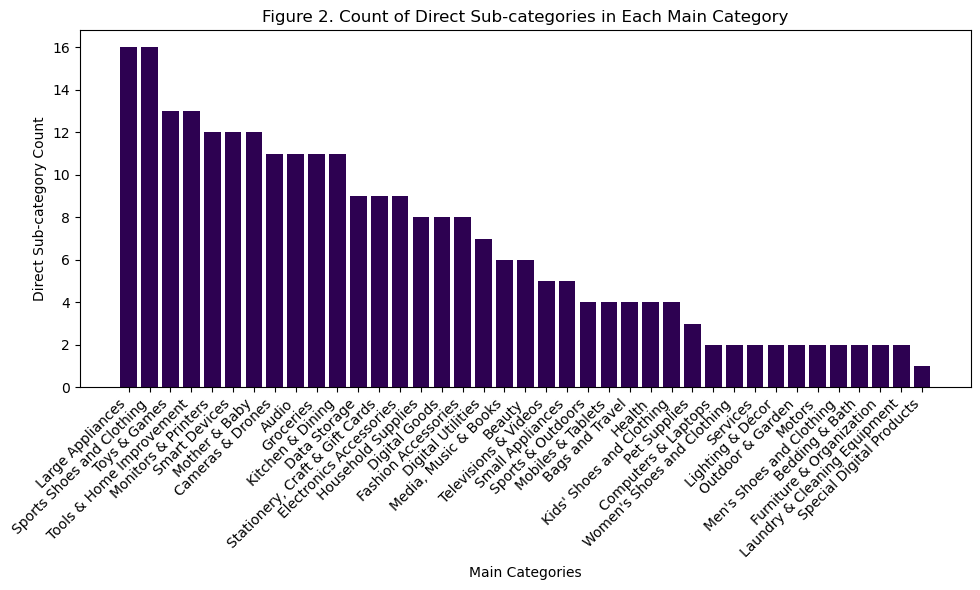

```python
categories = {}

for item in all_cat_path_list:
    split_items = item.split(' > ')
    if len(split_items) >= 2:
        category = split_items[0]
        subcategory = split_items[1]
        if category not in categories:
            categories[category] = set()
        categories[category].add(subcategory)

unique_counts = {category: len(subcategories) for category, subcategories in categories.items()}
sorted_categories = dict(sorted(unique_counts.items(), key=lambda x: x[1], reverse=True))

plt.figure(figsize=(10, 6))
plt.bar(sorted_categories.keys(), sorted_categories.values(), color='#2D0151')
plt.xlabel('Main Categories')
plt.ylabel('Direct Sub-category Count')
plt.title('Figure 2. Count of Direct Sub-categories in Each Main Category')
plt.xticks(rotation=45, ha='right')
plt.tight_layout()

plt.show()
```

# DATA VECTORIZATION AND FEATURE ENGINEERING

[figure not shown]

## BAG-OF-WORDS REPRESENTATION

[figure not shown]

```python
final_lzd_df = pd.read_csv('df_lazada.csv')
```

```python
def bow_representation(df):
    """Create a bag-of-words representation
    """
    lzd_product_names = df['name'].tolist()
    count_vect = CountVectorizer(stop_words='english',
                                 token_pattern=r'[a-z-]{3,}',
                                 max_features=5000)
    lzd_product_names = df['name'].tolist()
    lzd_bow = count_vect.fit_transform(lzd_product_names)
    feature_names = count_vect.get_feature_names_out()
    bow_df = pd.DataFrame(lzd_bow.toarray(), columns=feature_names)
    return bow_df, feature_names
```

```python
lzd_bow = bow_representation(final_lzd_df)
```

```python
def create_bow_df(df, lzd_bow):
    """Create a bag-of-words DataFrame
    """
    lzd_product_names = df['name'].tolist()
    count_vect = CountVectorizer(token_pattern=r"\S+")
    lzd_bow = count_vect.fit_transform(lzd_product_names)
    feature_names = count_vect.get_feature_names_out()
    bow_df = pd.DataFrame(lzd_bow.toarray(), columns=feature_names)

    return bow_df
```

```python
bow_df = create_bow_df(final_lzd_df, lzd_bow)
```

```python
start = 20
end = 22

rows_to_process = final_lzd_df['name'].iloc[start:end]
words_list = [word.lower() for row in rows_to_process for word in row.split()]

filtered_bow_df = bow_df[bow_df.columns.intersection(words_list)]
filtered_bow_df = filtered_bow_df[start:end]
filtered_bow_df.index = list(rows_to_process)
```

With the data collected, the text from the product names can be represented as vectors. Bag-of-words (BoW) representation can be used to achieve this. It works by representing the values of the actual text via its frequency, with each row representing an individual product name, and the columns as individual text.

#### 1. Break Down the Product Name into Terms:

[figure not shown]

- Consider the product name `Night Cap Simple Studio Summer Hat Bucket Hat For women`. The first step is to split this name into individual terms (words).

#### 2. Calculate Word Frequency:

[figure not shown]

- For each term in this product name, count the frequency and assign to the matrix.

Displayed below is a sample snapshot of a section in the bag-of-words representation.

```python
filtered_bow_df
```

|  | [uv-08] | baguio | beach | bucket | cap | city | farming | for | hat | la | ... | presa | protection | shop | simple | stop | studio | summer | sun | women | \| |
| --- | --- | --- | --- | --- | --- | --- | --- | --- | --- | --- | --- | --- | --- | --- | --- | --- | --- | --- | --- | --- | --- |
| Night Cap Simple Studio Summer Hat Bucket Hat For women | 0 | 0 | 0 | 1 | 1 | 0 | 0 | 1 | 2 | 0 | ... | 0 | 0 | 0 | 1 | 0 | 1 | 1 | 0 | 1 | 0 |
| [UV-08] LARGE Sun Protection Hat Beach Hat Farming Hat La Presa Baguio City \| Stop Ober Shop | 1 | 1 | 1 | 0 | 0 | 1 | 1 | 0 | 3 | 1 | ... | 1 | 1 | 1 | 0 | 1 | 0 | 0 | 1 | 0 | 1 |

2 rows × 23 columns

## BAG of WORDS WITH TF-IDF

[figure not shown]

TF-IDF works as an extension to the bag-of-words wherein it can take into account the importance of words relative to their occurence in the corpus. In turn, it can help to reduce the importance of common words.

For the purpose of being able to properly group words into underlying topics during the dimensionality reduction analysis, bag-of-words with TF-IDF applied will be used instead. This is to eliminate words that are used across most listings and reduce noise to improve analysis performance.

#### 1. Break Down the Product Name into Terms:

[figure not shown]

- Consider the product name `Night Cap Simple Studio Summer Hat Bucket Hat For women`. The first step is to split this name into individual terms (words).

#### 2. Calculate Term Frequency (TF):

[figure not shown]

- For each term in this product name, calculate the TF. The TF is the frequency of the term in this product name compared to the total number of terms in the name.
- The formula for TF of a term `t` is: `TF(t) = (Number of times term t appears in a document) / (Total number of terms in the document)`.

#### 3. Calculate Inverse Document Frequency (IDF):

[figure not shown]

- Next, calculate the IDF for each term. This involves determining how many product names contain the term across the entire dataset.
- The formula for IDF of a term `t` is: `IDF(t) = log e [ n / df(t) ] + 1`, where `n` is the total number of documents (products) and `df(t)` is the number of documents containing term `t`. By adding 1, we ensure that the IDF is never zero. This is important because a zero IDF would nullify the weight of that term in TF-IDF calculations, potentially ignoring important terms that are common but still significant. In addition, it gives a slight boost to the importance of rarer terms in the dataset.

#### 4. Compute TF-IDF Score:

[figure not shown]

- For each term in the product name, calculate the TF-IDF score, which is the product of TF and IDF.
- The formula for TF-IDF is: `TF-IDF(t) = TF(t) × IDF(t)`.

In terms of parameters, the following were set:

- stop words were set to 'english' in order to remove common English words from the representation (e.g. 'the', 'and', 'is')
- token pattern was set to words containing alphabetical characters and hyphens, with a minimum length of 3, in order to remove noise coming from shorter words (e.g. 'm', 'xl', 'pc')
- max features was limited to 5,000 based on the term frequency of the dataset, to manage computational efficiency once dimensionality reduction is conducted.

By applying these steps to the `name` column, we can determine the relative importance of each term in the context of the entire dataset.

```python
def bow_tfidf_representation(df):
    """Create a TD-IDF representation
    """
    tfidf_vect = TfidfVectorizer(stop_words='english',
                                 token_pattern=r'[a-z-]{3,}',
                                 max_features=5000)
    lzd_product_names = df['name'].tolist()
    lzd_bow_tfidf = tfidf_vect.fit_transform(lzd_product_names)
    vocabulary_lzda = tfidf_vect.get_feature_names_out()
    return lzd_bow_tfidf, vocabulary_lzda
```

```python
lzd_bow_tfidf, vocabulary_lzda = bow_tfidf_representation(final_lzd_df)
df_lzd_bow_tfidf = pd.DataFrame.sparse.from_spmatrix(lzd_bow_tfidf, columns=vocabulary_lzda)
```

```python
def df_tfidf_snippet(df_lzd_bow_tfidf, final_lzd_df):
    df_lzd_bow_tfidf_snippet = df_lzd_bow_tfidf.iloc[:300, -20:]
    nonzero_cells = df_lzd_bow_tfidf_snippet.stack()[df_lzd_bow_tfidf_snippet.stack() != 0]
    nonzero_index = [ind for ind, v in nonzero_cells.index][:3]
    column_name = final_lzd_df.iloc[nonzero_index, 1]
    pd.options.display.float_format = " {:,.5f}".format
    df_lzd_bow_tfidf_snippet = df_lzd_bow_tfidf.iloc[nonzero_index, -20:]
    return  df_lzd_bow_tfidf_snippet.set_index(column_name)
```

```python
df_tfidf_snippet(df_lzd_bow_tfidf, final_lzd_df)
```

| name | yongnuo | young | youth | youtube | yoyo | yrs | zania | zapatillas | zero | zhoukan | zinc | zip | zipper | zippered | zippers | zjw | zkteco | zone | zoom | zumba |
| --- | --- | --- | --- | --- | --- | --- | --- | --- | --- | --- | --- | --- | --- | --- | --- | --- | --- | --- | --- | --- |
| Sun Hat unisex Sunscreen Cap 360 Degree Cover Zipper Design Folding Quick-Drying Cap Breathable Mask ice silk | 0.00000 | 0.00000 | 0.00000 | 0.00000 | 0.00000 | 0.00000 | 0.00000 | 0.00000 | 0.00000 | 0.00000 | 0.00000 | 0.00000 | 0.22061 | 0.00000 | 0.00000 | 0.00000 | 0.00000 | 0.00000 | 0.00000 | 0.00000 |
| Bear Jumper Denim maong for boys 0-5yrs | 0.00000 | 0.00000 | 0.00000 | 0.00000 | 0.00000 | 0.39247 | 0.00000 | 0.00000 | 0.00000 | 0.00000 | 0.00000 | 0.00000 | 0.00000 | 0.00000 | 0.00000 | 0.00000 | 0.00000 | 0.00000 | 0.00000 | 0.00000 |
| unisex kids jogger 2/12 yrs old kids supplier here my all items is onhand ready to ship and all items is good quality ready to ship | 0.00000 | 0.00000 | 0.00000 | 0.00000 | 0.00000 | 0.21420 | 0.00000 | 0.00000 | 0.00000 | 0.00000 | 0.00000 | 0.00000 | 0.00000 | 0.00000 | 0.00000 | 0.00000 | 0.00000 | 0.00000 | 0.00000 | 0.00000 |

- This is a snippet of the vectorized bag of words using TFIDF.

# DIMENSIONALITY REDUCTION ANALYSIS

[figure not shown]

With the vectorized data prepared, dimensionality reduction analysis can be conducted. In the team's case, non-negative matrix factorization was chosen as the ideal dimensionality reduction analysis method due to the following considerations:

- sparse dataset: TF-IDF matrices are often sparse, and NMF tends to preserve sparsity in the data, which is essential when dealing with text data. PCA on the otherhand involves centering the data by subtracting the mean. In the case of sparse data, where many values are zero, the mean may not accurately represent the center of the data. This can lead to a biased representation and may not effectively capture the principal components.
- non-negativity constraint: NMF enforces non-negativity constraints on its factors, leading to a parts-based representation. In the context of TF-IDF matrices representing product names, this constraint aligns well with the idea that each term or topic should have a positive contribution, making the factors more interpretable.
- topic extraction: NMF has been shown to be effective in extracting topics from text data. Since product names are textual in nature, NMF can capture latent topics that can be considered as groups and interpreted as categories.

While Truncated SVD, and specifically LSA was considered as a valid method, the results were less interpretable **(Appendix 1. LSA Results)**, leading the team to choose NMF as the ideal dimensionality reduction method instead.

A crucial step when conducting NMF is determing the appropriate or optimal number of components to split or group the words with. This is where metrics such as reconstruction error and silhouette score come in.

## RECONSTRUCTION ERROR

[figure not shown]

```python
def reconstruction_error(n_component, lzd_bow_tfidf):
    errors = []
    for n_component in n_components:
        nmf_ = NMF(n_component, max_iter=10000)
        nmf_.fit(lzd_bow_tfidf)
        errors.append(nmf_.reconstruction_err_)
    plt.figure(figsize=(10, 6))
    plt.plot(n_components, errors, '-o', color='#2D0151')
    plt.xticks(range(min(n_components), max(n_components) + 1, 2))
    plt.xlabel(r'$n_\text{components}$')
    plt.ylabel('Reconstruction Error');
```

The reconstruction error measures the dissimilarity between the original data and the data reconstructed from the reduced-dimensional representation obtained through NMF.

A lower reconstruction error can indicate a better approximate of the original dataset. By monitoring the reconstruction error, we can help ensure the dimensionality reduction does not sacrifice too much information.

Observing the results, the elbow point does not stand out immediately due to the gradual change on the reconstruction error, as displayed in **Figure 3. Reconstruction Error for Optimal NMF Components.**

Due to this, a secondary metric was used to better determine the optimal number of groups.

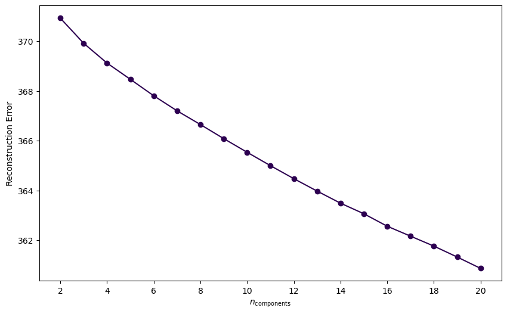

```python
n_component = 21
reconstruction_error(n_component, lzd_bow_tfidf)
```

## SILHOUETTE SCORE

[figure not shown]

```python
def silhouette_test(n_components, lzd_bow_tfidf):
    silhouette_scores = []

    for n_component in n_components:
        nmf_ = NMF(n_components=n_component, max_iter=1000)
        W = nmf_.fit_transform(lzd_bow_tfidf)
        cluster_labels = nmf_.transform(lzd_bow_tfidf).argmax(axis=1)
        silhouette_avg = silhouette_score(lzd_bow_tfidf, cluster_labels)
        silhouette_scores.append(silhouette_avg)
    return silhouette_scores
```

```python
n_components = range(2, 21)
silhouette_scores = silhouette_test(n_components, lzd_bow_tfidf)
```

```python
def plot_silhouette_scores(n_components, silhouette_scores):
    plt.figure(figsize=(10, 6))
    plt.plot(n_components, silhouette_scores, marker='o', color='#2D0151', linestyle='-', linewidth=2, markersize=8)

    # Highlight the maximum silhouette score
    max_score_index = silhouette_scores.index(max(silhouette_scores))
    max_score_x = n_components[max_score_index]
    max_score_y = max(silhouette_scores)

    plt.scatter(max_score_x, max_score_y, color='white', marker='o', s=200, label='Max Score')
    plt.annotate(f'Max Score: {max_score_y:.3f}',
                 xy=(.2 + max_score_x, -.001 + max_score_y),
                 xytext=(max_score_x + 4, max_score_y - 0.02),
                 arrowprops=dict(facecolor='blue', arrowstyle='->'),
                 fontsize=12)

    plt.xlabel(r'$n_\text{components}$', fontsize=14)
    plt.ylabel('Silhouette Score', fontsize=14)
    plt.title('Silhouette Method for Optimal NMF Components', fontsize=16)
    plt.xticks(range(min(n_components), max(n_components) + 1, 2))
    plt.show()
```

On the otherhand, the silhouette score is a measure of how similar an object is to its own cluster (cohesion) compared to other clusters (separation). It ranges from -1 to 1, with a higher score indicating better-defined groups. In the context of NMF, the silhoette score is particularly valuable with the goal of using reduced-dimensional representation for creating groups of topics.

A higher silhouette score suggests that the words within the groups are more similar to each other compared to words in other groups.

Based on the generated results in **Figure 4. Silhouette Method for Optimal NMF Components**, the number of groups that would give the highest silhouette score is at 7 groups. Additionally, the resulting score is close to zero, implying some overlap with the groups, or ambiguous boundaries. However this is expected with the dataset used, as products across different categories may have some overlaps.

Therefore, using the optimal number of groups indicated by the highest silhouette score ensures that the groups generated are those with the lowest possible amount of overlap.

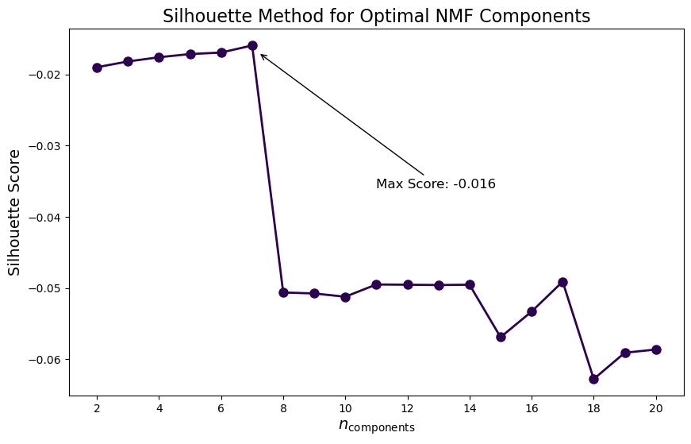

```python
plot_silhouette_scores(n_components, silhouette_scores)
```

```python
n_silhouette_max = silhouette_scores.index(max(silhouette_scores)) + 2
print(f'Optimal number of topics based on highest silhouette score: {n_silhouette_max}')
```

```
Optimal number of topics based on highest silhouette score: 7
```

## NON-NEGATIVE MATRIX FACTORIZATION (NMF)

[figure not shown]

### 1. Initialize NMF

[figure not shown]

```python
nmf = NMF(n_components=n_silhouette_max, max_iter=1000)
nmf
```

```
NMF(max_iter=1000, n_components=7)
```

### 2. Transform to Factorized Matrix object

[figure not shown]

```python
def U_snippet(lzd_bow_tfidf, final_lzd_df, topic_label):
    U_lzda = nmf.fit_transform(lzd_bow_tfidf)
    topic_label = [f'Topic {i}' for i in range(1, 8)]
    df_U_lzda = pd.DataFrame(U_lzda, columns=topic_label)
    df_U_lzda_snip = df_U_lzda.iloc[1:4, :]
    return df_U_lzda_snip.set_index(final_lzd_df['name'][1:4])
```

- Displayed below is the matrix U transformed to a DataFrame, with the rows corresponding to all of the product names, and columnes corresponding to the identified topics, or to be used for category interpretations.

```python
topic_label = [f'Topic {i}' for i in range(1, 8)]
U_snippet(lzd_bow_tfidf, final_lzd_df, topic_label)
```

| name | Topic 1 | Topic 2 | Topic 3 | Topic 4 | Topic 5 | Topic 6 | Topic 7 |
| --- | --- | --- | --- | --- | --- | --- | --- |
| Unisex Short Brim Sun Fedora Hat with Solid Band (Black) | 0.00556 | 0.00333 | 0.00226 | 0.00000 | 0.00308 | 0.00749 | 0.00000 |
| Summer Hat Plain Reversible double side Women's fisherman hat Bucket Hat Beach Hat | 0.00829 | 0.00155 | 0.00170 | 0.00000 | 0.00308 | 0.00000 | 0.00270 |
| Summer Ladies Sun Hat Sun Protection UV Protection Big Brim With Breathable Mesh Mask Design Hat | 0.00657 | 0.00260 | 0.00167 | 0.00000 | 0.00569 | 0.00239 | 0.00375 |

```python
V_lzda = nmf.components_
V_snippet = pd.DataFrame(V_lzda, columns=vocabulary_lzda, index = topic_label)
V_snippet
```

|  | -channel | -core | -degree | -in- | -inch | -layer | -led | -pack | -piece | -pin | ... | zinc | zip | zipper | zippered | zippers | zjw | zkteco | zone | zoom | zumba |
| --- | --- | --- | --- | --- | --- | --- | --- | --- | --- | --- | --- | --- | --- | --- | --- | --- | --- | --- | --- | --- | --- |
| Topic 1 | 0.00000 | 0.00000 | 0.00000 | 0.00000 | 0.00000 | 0.00000 | 0.00000 | 0.00212 | 0.00000 | 0.00000 | ... | 0.00000 | 0.01513 | 0.05564 | 0.00008 | 0.00017 | 0.00000 | 0.00000 | 0.00000 | 0.03528 | 0.01655 |
| Topic 2 | 0.00000 | 0.00073 | 0.00000 | 0.00392 | 0.00027 | 0.00000 | 0.00000 | 0.00365 | 0.04792 | 0.00000 | ... | 0.00857 | 0.02028 | 0.02637 | 0.00294 | 0.00376 | 0.00823 | 0.00076 | 0.00055 | 0.00000 | 0.00976 |
| Topic 3 | 0.00000 | 0.00000 | 0.00084 | 0.00226 | 0.00859 | 0.00000 | 0.00000 | 0.00000 | 0.00047 | 0.00000 | ... | 0.00068 | 0.02548 | 0.22858 | 0.00834 | 0.00727 | 0.00000 | 0.00000 | 0.00185 | 0.00000 | 0.00000 |
| Topic 4 | 0.00201 | 0.00000 | 0.00257 | 0.00147 | 0.00940 | 0.00000 | 0.00000 | 0.00220 | 0.00000 | 0.00000 | ... | 0.00000 | 0.00000 | 0.00000 | 0.00000 | 0.00011 | 0.00590 | 0.00000 | 0.00052 | 0.11602 | 0.00000 |
| Topic 5 | 0.00000 | 0.00000 | 0.00053 | 0.01521 | 0.00511 | 0.00000 | 0.00000 | 0.00096 | 0.00000 | 0.00000 | ... | 0.00009 | 0.00000 | 0.00468 | 0.00000 | 0.00000 | 0.00000 | 0.00000 | 0.00412 | 0.00000 | 0.00076 |
| Topic 6 | 0.00618 | 0.00613 | 0.00207 | 0.02637 | 0.05893 | 0.00000 | 0.02299 | 0.00665 | 0.00000 | 0.01386 | ... | 0.00615 | 0.00908 | 0.01887 | 0.00000 | 0.00085 | 0.00913 | 0.01098 | 0.00079 | 0.00624 | 0.00030 |
| Topic 7 | 0.00000 | 0.00000 | 0.00466 | 0.02491 | 0.01227 | 0.03249 | 0.00000 | 0.00139 | 0.01552 | 0.00126 | ... | 0.00309 | 0.00000 | 0.04271 | 0.00365 | 0.00214 | 0.00000 | 0.00000 | 0.00223 | 0.00000 | 0.00233 |

7 rows × 5000 columns

```python
def graph_truncated_svd(lzd_bow_tfidf, n_silhouette_max, svd_x_axis, svd_y_axis, U_lzda):
    svd = TruncatedSVD(n_components=n_silhouette_max)
    X_svd = svd.fit_transform(lzd_bow_tfidf)

    plt.figure(figsize=(10, 8))
    plt.scatter(X_svd[:, svd_x_axis], X_svd[:, svd_y_axis], c=U_lzda.argmax(axis=1), cmap='plasma')

    # Add colorbar for reference
    cbar = plt.colorbar()
    cbar.set_label('Topic', rotation=270, labelpad=15)

    plt.xlabel(f'Component {svd_x_axis}')
    plt.ylabel(f'Component {svd_y_axis}')
    plt.title('Figure 5. Visualization of NMF Topics')
    plt.show()
```

The results of the NMF with 7 generated topics can be visualized by plotting with Trunctaed SVD, as displayed in **Figure 5. Visualization of NMF Topics**, and using the seven topics as the hues to differentiate each group.

As the silhouette score suggests, there are areas with overlap, as expected with the nature of the dataset. However the groups are relatively distinct.

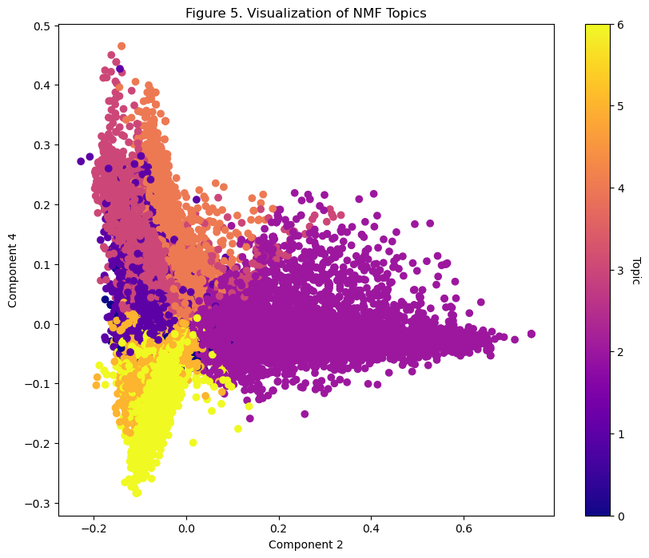

```python
# Graph NMF with SVD, Set SVD1 and SVD2 to display
svd_x_axis = 2
svd_y_axis = 4
graph_truncated_svd(lzd_bow_tfidf, n_silhouette_max, svd_x_axis, svd_y_axis, U_lzda)
```

# RESULTS

[figure not shown]

```python
def top_per_topic(V_lzda, n_topics, vocabulary_lzda, categories, words_per_topic):
    top_words_per_topic = {}
    for idx, topic in enumerate(V_lzda):
        top_idx = topic.argsort()[::-1][:n_per_topic]
        top_words_per_topic[f'{categories[idx]}\n'] = vocabulary_lzda[top_idx]
    return top_words_per_topic
```

Using 7 as the optimal number of groups to find underlying topics, the following sets of words were generated from the results of the NMF.

These group of words were then interpreted into 7 category names.

```python
def topics_word_cloud(top_words_per_topic):
    color_map = LinearSegmentedColormap.from_list("pink_purple", ["pink", "purple"])
    fig, axes = plt.subplots(nrows=3, ncols=3, figsize=(20, 20))
    for i, (category, text_list) in enumerate(top_words_per_topic.items(), 1):
        if i <= 9:
            wc = WordCloud(
                background_color="white",
                max_words=2000,
                contour_width=1,
                contour_color='black',
                colormap=color_map
            )
            wc.generate(" ".join(text_list))
            axes[(i-1)//3, (i-1)%3].imshow(wc, interpolation='bilinear')
            axes[(i-1)//3, (i-1)%3].axis("off")
            axes[(i-1)//3, (i-1)%3].set_title(category, fontsize=25)
    for i in range(len(top_words_per_topic), 9):
        axes[i//3, i%3].axis('off')
    plt.subplots_adjust(wspace=0.20, hspace=-0.5)
    plt.suptitle('Fig 6. Lazada Key Categories')
    plt.show()
```

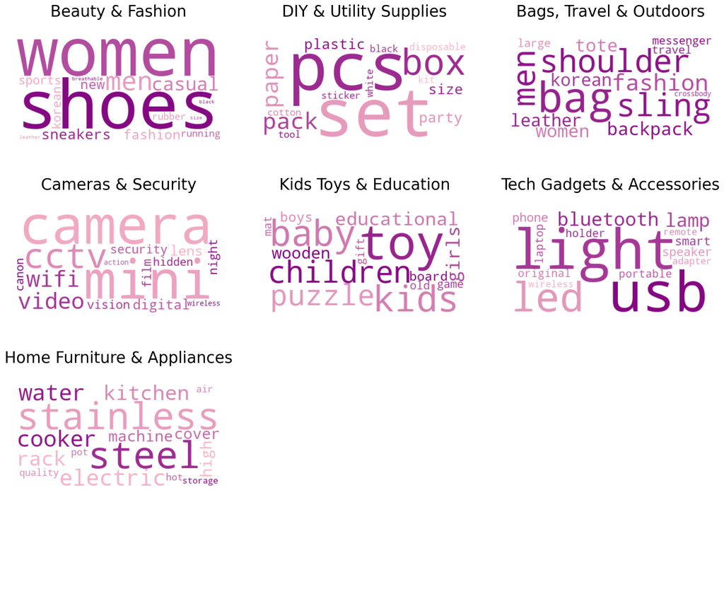

```python
categories = ['Beauty & Fashion', 'DIY & Utility Supplies', 'Bags, Travel & Outdoors', 'Cameras & Security', 'Kids Toys & Education', 'Tech Gadgets & Accessories', 'Home Furniture & Appliances']
top_words_per_topic =  top_per_topic(V_lzda, n_topics, vocabulary_lzda, categories, words_per_topic=15)
topics_word_cloud(top_words_per_topic)
```

# CONCLUSION & INSIGHTS

[figure not shown]

Through the application of TF-IDF on LAZADA product names and subsequent Non-negative Matrix Factorization (NMF) with silhouette analysis, the team successfully restructured the categories from **42** down to **7**.

The seven categories are Beauty & Fashion, DIY & Utility Supply, Bags, Travel & Outdoor, Cameras & Security, Kids Toys & Education, Tech Gadgets & Accessories, and Home Furniture & Appliances. This restructuring significantly **improved user experience** by **simplifying navigation** and **enhancing product recommendations**.

This success underscores the importance of leveraging data mining and wrangling techniques to **optimize e-commerce platforms**, ensuring their continued relevance and competitiveness in the dynamic online retail landscape.

# FURTHER RECOMMENDATIONS

[figure not shown]

The further recommendations of the team are the following:

1. **Explore Product Associations for Cross-Selling**: Establish correlations among related items within the consolidated categories with view to develop product bundles or recommendations to cross-sell and increase sales.
2. **Refine Search and Filtering by Condensed Categories**: Improve searches and filters that match the new category structure to simplify navigation and facilitate products’ discovery in updated categories.
3. **Monitor User Feedback for Iterative Enhancements**: Keep collecting feedback from users about the refined categories so that they are constantly usable and responsive to current user preferences for continuous engagement and satisfaction.

# BUSINESS VALUE

[figure not shown]

By reducing the number of categories from 42 to 7, our project helps Lazada **organize and simplify** their product categories on their website. This allows customers to easily find their desired products, leading to an **enhanced customer experience** and **increased sales**. Moreover, this streamlined categorization system could serve as a **competitive advantage** for Lazada, potentially leading to **higher user retention and acquisition rates**.

# APPENDIX

[figure not shown]

### Appendix 1. LSA Results

[figure not shown]

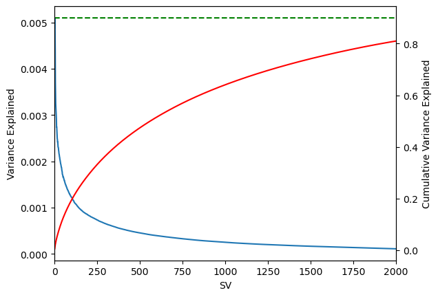

```python
def LSA_method(final_lzd_df):
    vectorizer = TfidfVectorizer(stop_words='english',
                                     token_pattern=r'[a-z-]{3,}',
                                     max_features=5000)
    bow_lzda = vectorizer.fit_transform(final_lzd_df['name'].tolist())
    feature_names = vectorizer.get_feature_names_out()

    svd = TruncatedSVD(n_components=2000)
    svd.fit(bow_lzda)

    explained_variance_ratio = svd.explained_variance_ratio_
    cumulative_explained_variance = np.cumsum(explained_variance_ratio)

    fig, ax = plt.subplots()
    ax.plot(range(1, len(explained_variance_ratio) + 1), explained_variance_ratio, '-', label='individual')
    ax.set_xlim(0, len(explained_variance_ratio) + 1)
    ax.set_xlabel('SV')
    ax.set_ylabel('Variance Explained')
    ax = ax.twinx()
    ax.plot(range(1, len(explained_variance_ratio) + 1), cumulative_explained_variance, 'r-', label='cumulative')
    ax.axhline(0.9, ls='--', color='g')  # Horizontal line at 90% variance explained
    ax.set_ylabel('Cumulative Variance Explained')
    plt.show()

LSA_method(final_lzd_df)
```

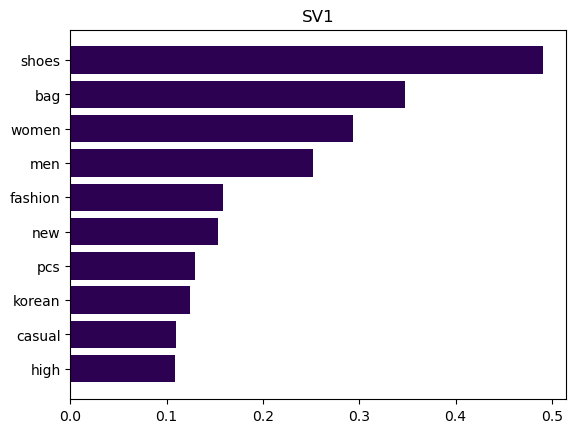

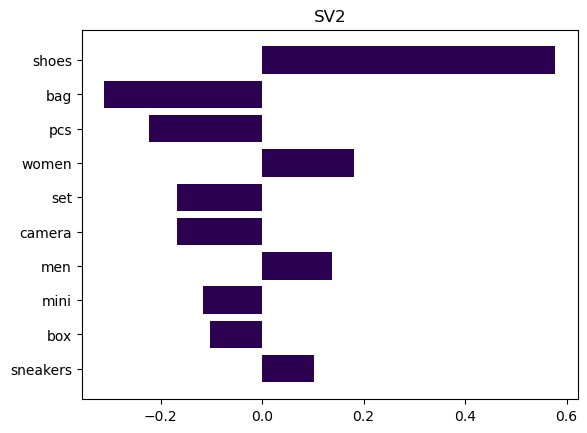

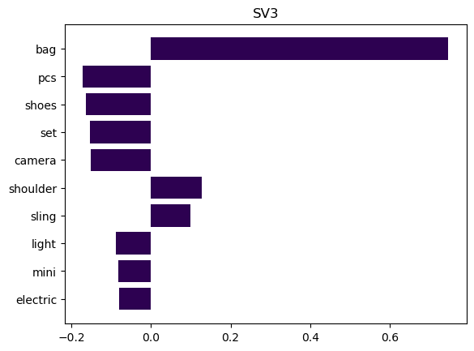

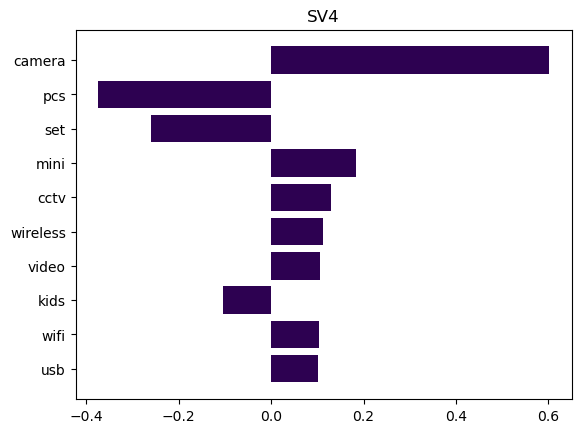

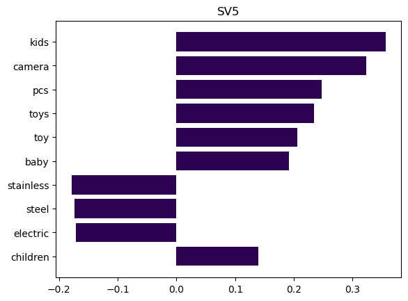

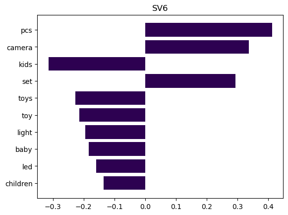

```python
for i in range(6):
    fig, ax = plt.subplots()
    order = np.argsort(np.abs(svd.components_[i]))[-10:]
    ax.barh([feature_names[o] for o in order], svd.components_[i][order], color='#2D0151' )
    ax.set_title(f'SV{i+1}')
    plt.show()
```

# REFERENCES

[figure not shown]

"Lazada Open Platform." Lazada, 24 November 2023, https://open.lazada.com/.

"Lazada Philippines." Lazada, 24 November 2023, [https://www.lazada.com.ph/?spm=a2o4l.searchlist.header.dhome.4d2f4269DMla5M."Lazada](https://www.lazada.com.ph/?spm=a2o4l.searchlist.header.dhome.4d2f4269DMla5M.%22Lazada) Philippines."

ChatGPT. "Conversation on TFIDF, NMF, and Silhouette analysis." Personal interview. 24 November 2023.

Wu, Songhao. "Web Scraping Basics: How to Scrape Data from a Website in Python." Towards Data Science, Medium, 15 July 2020, https://towardsdatascience.com/web-scraping-basics-82f8b5acd45c.

Actowiz Solutions. "The Ultimate Guide to Scrape Lazada Product Data." Medium, 14 July [Year], https://medium.com/@actowizsolutions/the-ultimate-guide-to-scrape-lazada-product-data-c256a6c0b0aa.

K. R. Shahapure and C. Nicholas, "Cluster Quality Analysis Using Silhouette Score," 2020 IEEE 7th International Conference on Data Science and Advanced Analytics (DSAA), Sydney, NSW, Australia, 2020, pp. 747-748, doi: 10.1109/DSAA49011.2020.00096.

Jain, A. (2021, November 11). How Sklearn’s TfidfVectorizer Calculates TF-IDF Values. Analytics Vidhya. https://www.analyticsvidhya.com/blog/2021/11/how-sklearns-tfidfvectorizer-calculates-tf-idf-values/Jain, A. (2021, November 11). How Sklearn’s TfidfVectorizer Calculates TF-IDF Values. Analytics Vidhya. https://www.analyticsvidhya.com/blog/2021/11/how-sklearns-tfidfvectorizer-calculates-tf-idf-values/